# Exercises: Mixed Effects Models

Mixed effects models are powerful statistical tools that allow us to analyze data with hierarchical or grouped structures. In these exercises, we will explore the use of mixed models in R.

You will be using the `lme4` package for fitting mixed models and you need to install this package. In the examples we will use `tidyverse` for data manipulation and `ggplot2` for visualization, but if you prefer other alternatives, that is of course fine.

```r
library(lme4)
library(tidyverse)
library(ggplot2)
```

# 1 Random intercept and slope

In these exercises we cover both models with **random intercept** and **random slope** using the `lme4` package in R.

**Exercise 1 (Drug effect on blood pressure)** A study investigates how a drug affects blood pressure. 200 patients are recruited at 10 hospitals. We suspect that the average blood pressure differs between hospitals, mainly due to different routines for measurement, but we expect the drug effect to be consistent.

```r
## Generate the data
databp <- data.frame(hospital=factor(rep(1:10, each=20)),
                 drug=rep(c("placebo", "treatment"), times=100),
                 bp=c(123.9,114.6,119.8,113.3,115.0,121.7,120.2,102.9,121.3,110.4,112.4,111.7,112.6,109.1,114.6,104.3,121.9,113.5,112.1,119.0,121.2,112.6,123.6,118.5,123.2,117.5,121.8,113.8,117.5,112.2,115.6,113.0,112.8,124.9,125.1,108.5,117.1,111.7,123.0,113.7,127.5,121.1,126.0,128.1,125.1,128.8,118.5,124.2,126.9,122.3,128.1,118.7,124.6,116.1,120.9,122.8,128.5,121.5,130.8,131.5,117.8,103.7,125.3,111.7,116.8,120.4,118.9,109.2,121.2,114.6,120.3,117.2,118.4,118.5,119.2,116.9,125.8,117.5,118.7,121.0,125.5,118.3,121.7,112.4,127.3,112.5,131.5,123.2,119.3,110.4,117.0,116.8,119.3,113.8,115.8,115.3,116.6,107.2,118.6,120.1,124.0,124.9,118.8,121.6,129.5,123.4,127.4,118.7,122.6,116.7,127.4,117.1,124.4,120.6,136.1,118.6,128.0,122.3,122.1,121.5,129.1,119.1,122.0,114.7,111.6,122.5,114.5,120.5,131.4,109.6,125.4,115.5,114.0,109.3,113.8,114.2,114.5,120.3,132.3,110.4,118.9,113.8,116.6,104.9,114.3,108.5,117.8,108.1,119.8,108.1,120.2,104.7,108.6,126.1,112.9,111.4,118.1,107.5,117.5,111.8,116.2,112.6,117.1,122.9,113.5,106.8,117.4,113.8,119.4,110.0,111.9,118.6,115.5,107.9,116.1,111.3,122.8,112.7,121.0,109.8,119.3,111.6,118.7,108.7,111.7,123.2,121.2,107.0,115.2,107.3,129.2,119.8,116.9,115.9,116.1,110.8,114.3,110.2,126.5,112.9))
```

1. Visualize the data using e.g. boxplots or jitter plots, both overall and by hospital. Based on the plots, do you think there is variability in blood pressure across hospitals that has to be taken care of?

**Solution**

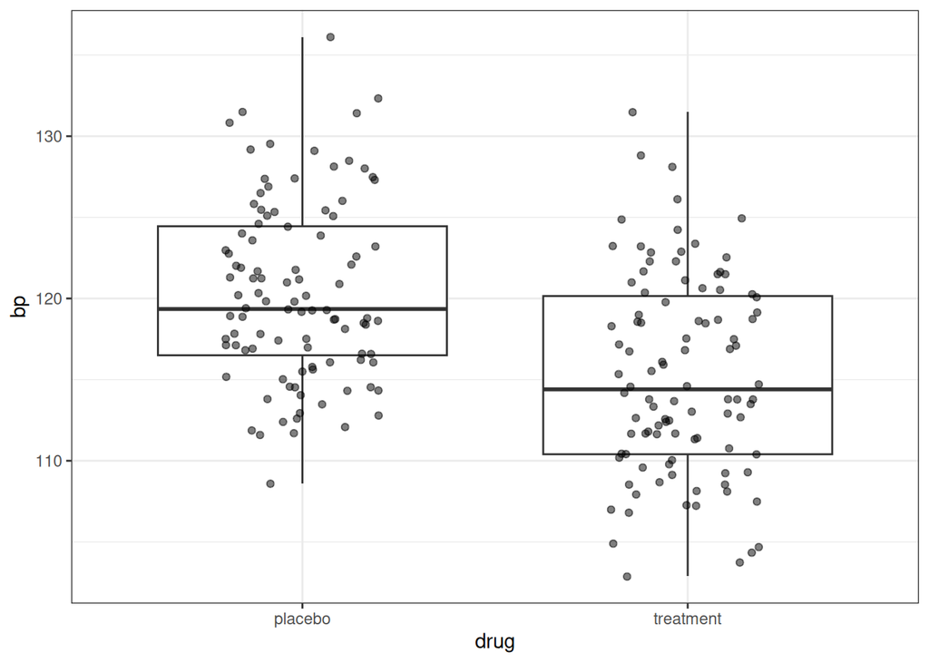

Figure 1: Blood pressure vs drug treatment, overall

```r
## Blood pressure vs drug treatment, treat each measurement as independent
databp %>%
  ggplot(aes(x = drug, y = bp)) +
  geom_boxplot() +
  geom_jitter(width = 0.2, alpha = 0.5) +
  theme_bw()
```

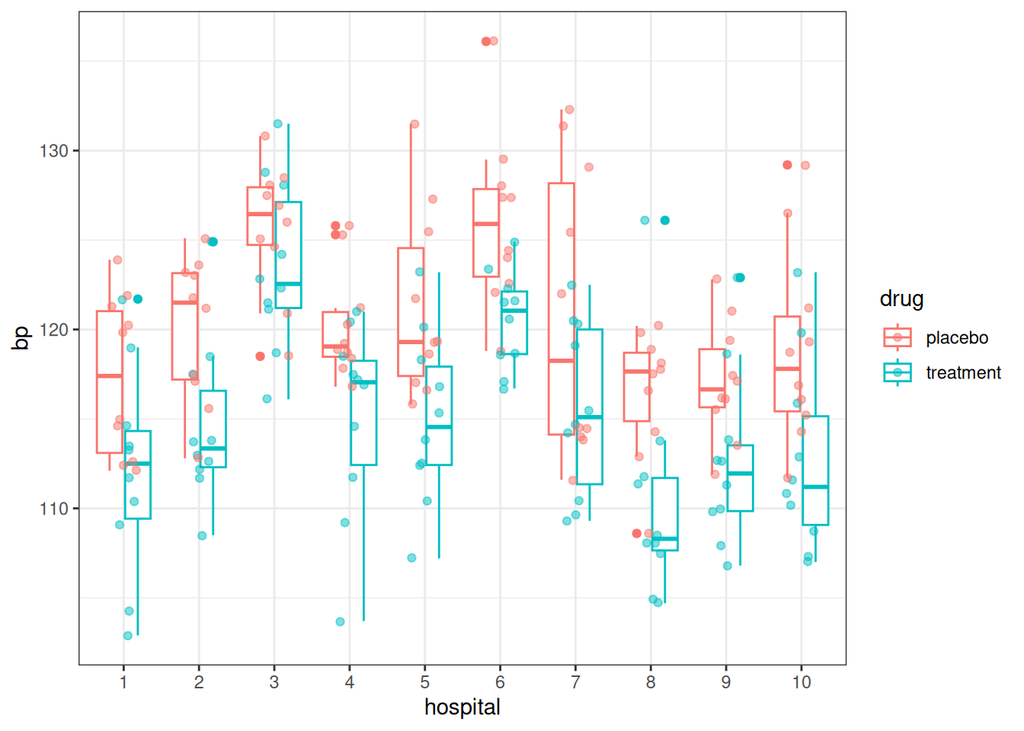

Figure 2: Blood pressure vs drug treatment, per hospital

```r
## Blood pressure per hospital and drug treatment
databp |>
  ggplot(aes(x = hospital, y = bp, color = drug)) +
  geom_boxplot() +
  geom_jitter(width = 0.2, alpha = 0.5) +
  theme_bw()
```

Yes, the plots suggest that there is variability in blood pressure across hospitals. The boxplots show different medians for each hospital, indicating that the baseline blood pressure differs between hospitals. This variability should be accounted for in our analysis.

2. If we ignore any grouping structure, we can fit an ordinary linear regression model. Fit a linear regression model to the data with blood pressure as the response variable and drug treatment as the independent variable. According to the linear regression model, is the average blood pressure higher in the treatment group compared to the placebo group? By how much does the drug change the blood pressure (on average)?

**Solution**

```r
lm_model <- lm(bp ~ drug, data = databp)
summary(lm_model)
```

```
Call:
lm(formula = bp ~ drug, data = databp)

Residuals:
    Min      1Q  Median      3Q     Max
-12.329  -4.302  -1.016   4.603  16.271

Coefficients:
              Estimate Std. Error t value Pr(>|t|)
(Intercept)   120.4020     0.5835 206.338  < 2e-16 ***
drugtreatment  -5.1730     0.8252  -6.269 2.24e-09 ***
---
Signif. codes:  0 '***' 0.001 '**' 0.01 '*' 0.05 '.' 0.1 ' ' 1

Residual standard error: 5.835 on 198 degrees of freedom
Multiple R-squared:  0.1656,    Adjusted R-squared:  0.1614
F-statistic:  39.3 on 1 and 198 DF,  p-value: 2.236e-09
```

The average blood pressure is lower in the treatment group compared to the placebo group. The estimated effect of the drug treatment on blood pressure is approximately -5.17, indicating that patients treated with the drug have an average blood pressure that is 5.17 units lower than those treated with the placebo.

3. Is this linear model a valid model given the data structure? Why/why not?

**Solution**

No, not really. The model treats all observations as independent, but patients within the same hospital may be more similar to each other than patients from different hospitals. This violates the independence assumption and can lead to incorrect standard errors and inference.

4. To account for the variability in blood pressure across hospitals, fit a mixed model with a random intercept for hospital. Random intercepts allow each hospital to have its own baseline blood pressure. Ivestigate the model using the functions `summary`, `varCorr`and `fixef`.

**Solution**

```r
model1 <- lmer(bp ~ drug + (1 | hospital), data = databp)
summary(model1)
```

[output not shown]

In addition to the summary function, try `VarCorr` and `fixef`. The function `VarCorr` gives the variance and correlations in a model, including the the variance of the random intercept for hospital. `fixef` extracts the estimated fixed effects of the model.

[output not shown]

7. Based on the variance due to the difference between hospitals, do you think it is appropriate to use an ordinary linear regression model instead of a mixed model? Why or why not?

**Tip**

The estimated between-hospital variability is substantial, indicating that there are significant differences in blood pressure between hospitals. This suggests that the ordinary linear regression is not appropriate.

8. The random intercepts for each hospital can be computed using the `ranef` function. This gives us the deviations from the overall mean (as reported by the fixed effect intercept) for each hospital.

Compute the random effects using `ranef`. Note that `ranef` gives the deviations from the overall mean for each hospital.

**Code**

```r
ranef(model1)
```

```
$hospital
   (Intercept)
1   -2.8246697
2   -0.4104221
3    6.1809293
4   -0.1462214
5    0.2865211
6    4.9829159
7    0.3821799
8   -3.9498001
9   -2.6880141
10  -1.8134188

with conditional variances for "hospital"
```

1. What would the average blood pressure be at hospital 3 for a patient treated with the placebo?

**Solution**

```r
fixef(model1)[1] + ranef(model1)$hospital[3,1]
```

```
(Intercept)
   126.5829
```

## 1.1 Sleep study

The `sleepstudy` dataset from the `lme4` package contains data on reaction times of subjects measured over several days of sleep deprivation (not allowed more than 3h of sleep).

Days 0 and 1 are adaptation and training and will be excluded. Day 2 is baseline, but for simplicity we will rename it to 0.

We will initially work with a subset of the data from only 5 subjects.

```r
##Remove the first two days (before baseline) and adjust Days to be 0 at baseline.
sleepall <- sleepstudy |> filter(Days>=2) |> mutate(Days=Days-2)
##Select a subset of 5 individuals
sleep <- sleepstudy |> filter(Subject %in% c(333, 334, 369, 349, 372), Days>=2) |> mutate(Days=Days-2)
```

Investigate the dataset. What columns are available? Plot the data, e.g. using ggplot and add a linear regression line to visualize the relationship between reaction time and days of sleep deprivation.

**Code**

```
   Reaction Days Subject
1  276.7693    0     333
2  299.8097    1     333
3  297.1710    2     333
4  338.1665    3     333
5  332.0265    4     333
6  348.8399    5     333
7  333.3600    6     333
8  362.0428    7     333
9  243.3647    0     334
10 254.6723    1     334
11 279.0244    2     334
12 284.1912    3     334
```

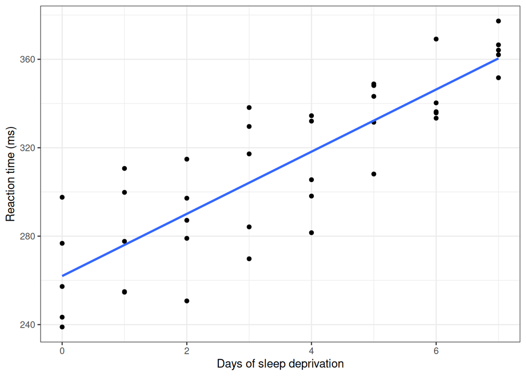

(a) Overall

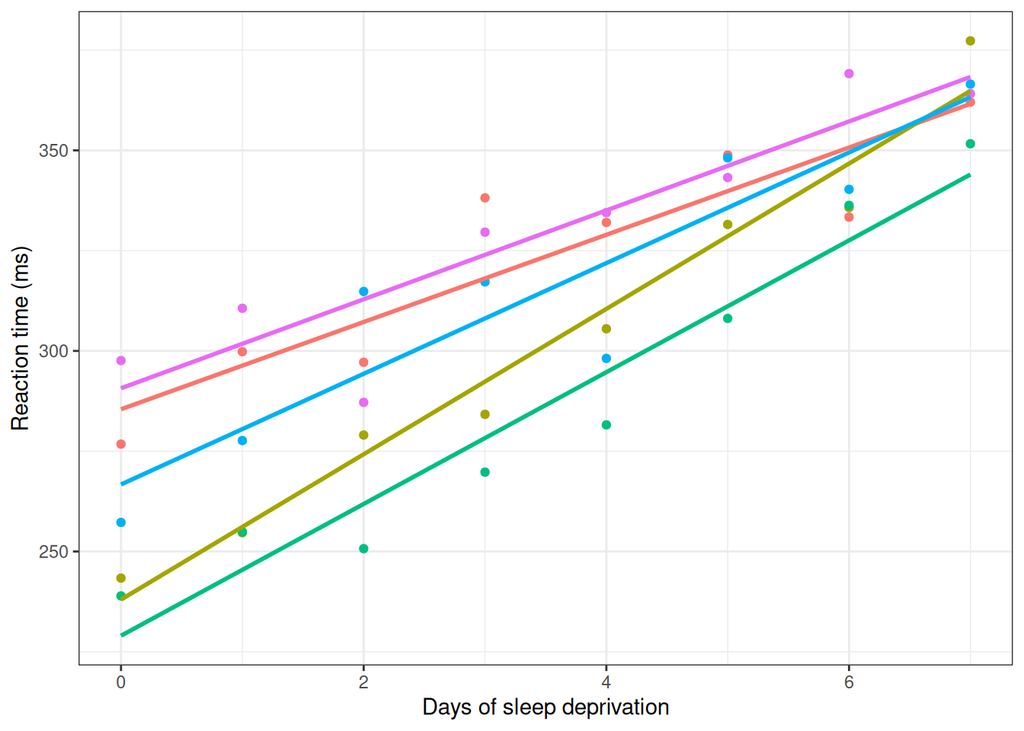

(b) Per subject

Figure 3: Reaction time vs Days of sleep deprivation

```r
head(sleep, 12)
##Plot Reaction time vs days of sleep deprivation, treat all measurements as independent
sleep |> ggplot(aes(x=Days, y=Reaction)) + geom_point() + geom_smooth(method="lm", se=FALSE) + theme_bw() +
  labs(x = "Days of sleep deprivation",
       y = "Reaction time (ms)")
##Plot Reaction time vs days of sleep deprivation, treating each subject as a separate group
sleep |> ggplot(aes(x=Days, y=Reaction, color=Subject)) + geom_point() + geom_smooth(method="lm", se=FALSE) +
  theme_bw() + theme(legend.position = "none") +
  labs(x = "Days of sleep deprivation",
       y = "Reaction time (ms)")
```

Fit a linear model to the data, ignoring the individual differences.

**Code**

```r
lm_sleep <- lm(Reaction ~ Days, data = sleep)
summary(lm_sleep)
```

```
Call:
lm(formula = Reaction ~ Days, data = sleep)

Residuals:
    Min      1Q  Median      3Q     Max
-39.385 -14.384   0.434  15.952  35.621

Coefficients:
            Estimate Std. Error t value Pr(>|t|)
(Intercept)  261.976      5.905   44.36  < 2e-16 ***
Days          14.060      1.412    9.96 3.82e-12 ***
---
Signif. codes:  0 '***' 0.001 '**' 0.01 '*' 0.05 '.' 0.1 ' ' 1

Residual standard error: 20.46 on 38 degrees of freedom
Multiple R-squared:  0.723, Adjusted R-squared:  0.7157
F-statistic:  99.2 on 1 and 38 DF,  p-value: 3.816e-12
```

According to this model, how many milliseconds does reaction time increase per day of sleep deprivation?

**Solution**

The model estimates that reaction time increases by approximately 14.060 milliseconds per day of sleep deprivation.

Fit a mixed model with a random intercept for each subject to account for individual differences in reaction time.

**Code**

```r
mm1_sleep <- lmer(Reaction ~ Days + (1 | Subject), data = sleep)
summary(mm1_sleep)
```

```
Linear mixed model fit by REML ['lmerMod']
Formula: Reaction ~ Days + (1 | Subject)
   Data: sleep

REML criterion at convergence: 325.3

Scaled residuals:
     Min       1Q   Median       3Q      Max
-1.79871 -0.71049 -0.07413  0.64819  1.91336

Random effects:
 Groups   Name        Variance Std.Dev.
 Subject  (Intercept) 278.9    16.70
 Residual             183.6    13.55
Number of obs: 40, groups:  Subject, 5

Fixed effects:
            Estimate Std. Error t value
(Intercept) 261.9758     8.4307   31.07
Days         14.0599     0.9351   15.04

Correlation of Fixed Effects:
     (Intr)
Days -0.388
```

According to this models, how many milliseconds does reaction time increase per day of sleep deprivation?

**Solution**

The model estimates that reaction time increases by approximately 14.060 milliseconds per day of sleep deprivation, which is the same as in the linear model.

How much variability in reaction time is explained by individual differences?

**Tip**

The estimated variance of the random intercept for Subject is 278.9, which indicates substantial between-subject variability in baseline reaction time.

Now, include the full dataset and redo the analyses, i.e. visualize and fit a mixed model with random intercept.

**Code**

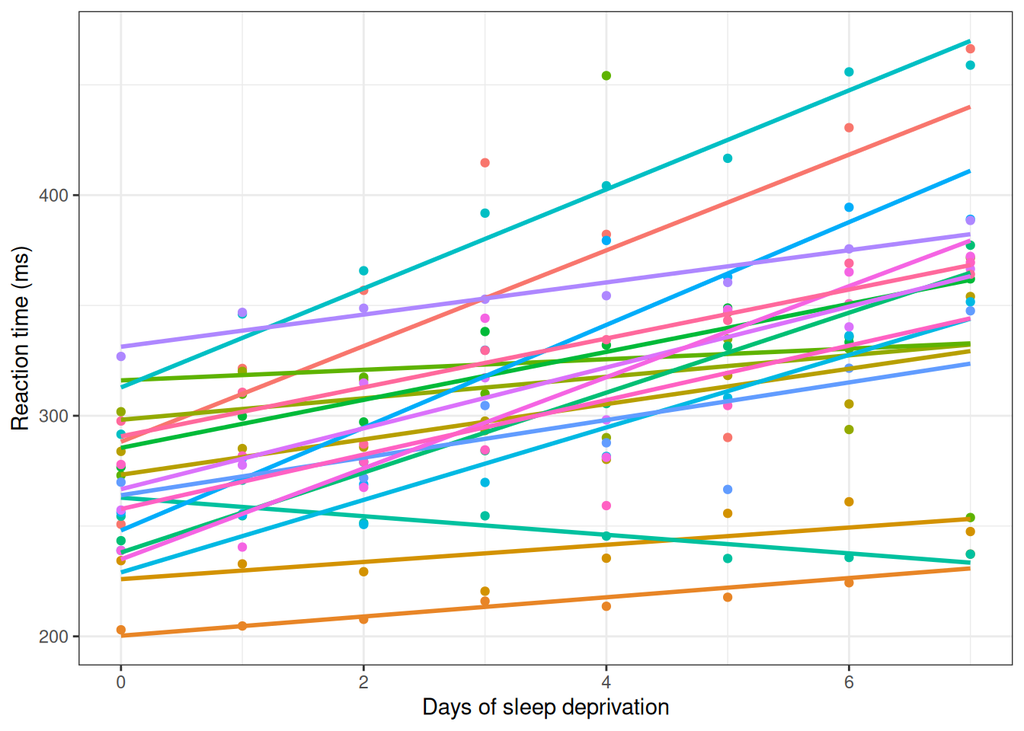

Figure 4: Reaction time vs Days of sleep deprivation

```r
sleepall |> ggplot(aes(x=Days, y=Reaction, color=Subject)) + geom_point() + geom_smooth(method="lm", se=FALSE) +
  theme_bw() + theme(legend.position = "none") +
  labs(x = "Days of sleep deprivation",
       y = "Reaction time (ms)")
```

```r
mm_sleepall <- lmer(Reaction ~ Days + (1 | Subject), data = sleepall)
summary(mm_sleepall)
```

```
Linear mixed model fit by REML ['lmerMod']
Formula: Reaction ~ Days + (1 | Subject)
   Data: sleepall

REML criterion at convergence: 1430

Scaled residuals:
    Min      1Q  Median      3Q     Max
-3.6261 -0.4450  0.0474  0.5199  4.1378

Random effects:
 Groups   Name        Variance Std.Dev.
 Subject  (Intercept) 1746.9   41.80
 Residual              913.1   30.22
Number of obs: 144, groups:  Subject, 18

Fixed effects:
            Estimate Std. Error t value
(Intercept)  267.967     10.871   24.65
Days          11.435      1.099   10.40

Correlation of Fixed Effects:
     (Intr)
Days -0.354
```

What is the estimated fixed effect of sleep deprivation on reaction time in the full dataset?

What is the estimated variability in reaction time explained by subject differences?

The plot suggests that also the slope varies between subjects, i.e. some subjects are more affected by sleep deprivation than others. Investigate this further by including a random slope for `Days` within `Subject`.

**Code**

```r
mm2_sleepall <- lmer(Reaction ~ Days + (Days | Subject), data = sleepall)
summary(mm2_sleepall)
```

```
Linear mixed model fit by REML ['lmerMod']
Formula: Reaction ~ Days + (Days | Subject)
   Data: sleepall

REML criterion at convergence: 1404.1

Scaled residuals:
    Min      1Q  Median      3Q     Max
-4.0157 -0.3541  0.0069  0.4681  5.0732

Random effects:
 Groups   Name        Variance Std.Dev. Corr
 Subject  (Intercept) 958.35   30.957
          Days         45.78    6.766   0.18
 Residual             651.60   25.526
Number of obs: 144, groups:  Subject, 18

Fixed effects:
            Estimate Std. Error t value
(Intercept)  267.967      8.266  32.418
Days          11.435      1.845   6.197

Correlation of Fixed Effects:
     (Intr)
Days -0.062
```

Based on the model with random slope, what is the average effect of sleep deprivation on reaction time? How does it compare to the model with only a random intercept?

Compute the random effects for the model with random slope using `ranef(mm2_sleepall)`. What is the estimated effect of sleep deprivation on reaction time for subject 309?

## 1.2 Orthodontic measurement over time

The `Orthodont` dataset from the `nlme` package contains orthodontic measurements of patients over time. The dataset includes measurements of the distance from the pituitary to the pterygomaxillary fissure (mm).

Use this dataset to study how the distance changes with age, accounting for individual differences in growth patterns. Also, take any relevant covariates into account.

```r
library(nlme)
data("Orthodont", package = "nlme")
```

Start by looking at the data table.

```r
summary(Orthodont)
```

```
    distance          age          Subject       Sex
 Min.   :16.50   Min.   : 8.0   M16    : 4   Male  :64
 1st Qu.:22.00   1st Qu.: 9.5   M05    : 4   Female:44
 Median :23.75   Median :11.0   M02    : 4
 Mean   :24.02   Mean   :11.0   M11    : 4
 3rd Qu.:26.00   3rd Qu.:12.5   M07    : 4
 Max.   :31.50   Max.   :14.0   M08    : 4
                                (Other):84
```

Visualize the data.

**Code**

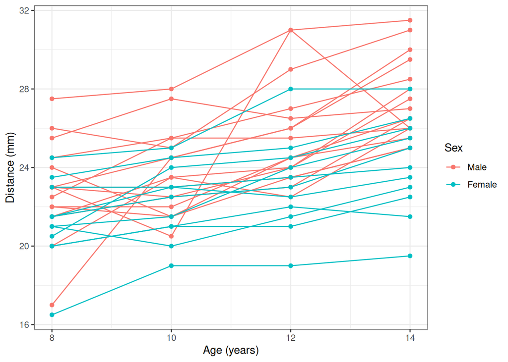

Figure 5

```r
Orthodont |>
  ggplot(aes(x = age, y = distance, group = Subject, color = Sex)) +
  geom_line() +
  geom_point() +
  xlab("Age (years)") +
  ylab("Distance (mm)") +
  theme_bw()
```

What is the grouping structure in the data?

What covariates could be relevant to include in the model?

First, fit a linear model to the data, ignoring the grouping structure, but include any relevant covariates.

Then, fit a mixed model taking the grouping structure into account. Use a random intercept for `Subject` to account for individual differences in growth patterns.

**Code**

The groups would be the individual subjects, and the covariates could be `age` and `Sex`.

```r
lmortho <- lm(distance ~ age + Sex, data=Orthodont)
summary(lmortho)
```

```
Call:
lm(formula = distance ~ age + Sex, data = Orthodont)

Residuals:
    Min      1Q  Median      3Q     Max
-5.9882 -1.4882 -0.0586  1.1916  5.3711

Coefficients:
            Estimate Std. Error t value Pr(>|t|)
(Intercept) 17.70671    1.11221  15.920  < 2e-16 ***
age          0.66019    0.09776   6.753 8.25e-10 ***
SexFemale   -2.32102    0.44489  -5.217 9.20e-07 ***
---
Signif. codes:  0 '***' 0.001 '**' 0.01 '*' 0.05 '.' 0.1 ' ' 1

Residual standard error: 2.272 on 105 degrees of freedom
Multiple R-squared:  0.4095,    Adjusted R-squared:  0.3983
F-statistic: 36.41 on 2 and 105 DF,  p-value: 9.726e-13
```

```r
mmortho <- lmer(distance ~ age + Sex + (1 | Subject), data=Orthodont)
summary(mmortho)
```

```
Linear mixed model fit by REML ['lmerMod']
Formula: distance ~ age + Sex + (1 | Subject)
   Data: Orthodont

REML criterion at convergence: 437.5

Scaled residuals:
    Min      1Q  Median      3Q     Max
-3.7489 -0.5503 -0.0252  0.4534  3.6575

Random effects:
 Groups   Name        Variance Std.Dev.
 Subject  (Intercept) 3.267    1.807
 Residual             2.049    1.432
Number of obs: 108, groups:  Subject, 27

Fixed effects:
            Estimate Std. Error t value
(Intercept) 17.70671    0.83392  21.233
age          0.66019    0.06161  10.716
SexFemale   -2.32102    0.76142  -3.048

Correlation of Fixed Effects:
          (Intr) age
age       -0.813
SexFemale -0.372  0.000
```

What is the estimated effect of age on distance in the linear model? How does it compare to the mixed model?

What is the estimated variability in distance due to differences between subjects? Does this suggest that the random intercept is needed in the model?

These exercises focus on more complex grouped structures with more than one grouping level as well as statistical tests for mixed models.

# 2 Nested design

## 2.1 Mice in litters

We simulate data for mice nested within litters, which are themselves nested within breeding lines. Our aim is to evaluate the effect of a drug on mouse weight while accounting for the hierarchical grouping structure.

```r
## Data simulation
set.seed(42)

# Parameters
n_lines <- 5
n_litters_per_line <- 4
n_mice_per_litter <- 6

# Create data
nested_data <- expand.grid(
  line = factor(1:n_lines),
  litter = factor(1:n_litters_per_line),
  mouse = 1:n_mice_per_litter
) %>%
  mutate(
    litter_id = factor(paste(line, litter, sep=".")),
    drug = sample(c("control", "treated"), n(), replace = TRUE),
    line_effect = rnorm(n_lines, 0, 1)[as.integer(line)],
    litter_effect = rnorm(n_lines * n_litters_per_line, 0, 0.8)[as.integer(litter_id)],
    residual = rnorm(n(), 0, 1),
    drug_effect = ifelse(drug == "treated", -2, 0),
    weight = 25 + drug_effect + line_effect + litter_effect + residual
  )
```

Visualize the data, e.g. using boxplots and jitter plots, both overall and showing the line and litter.

**Code**

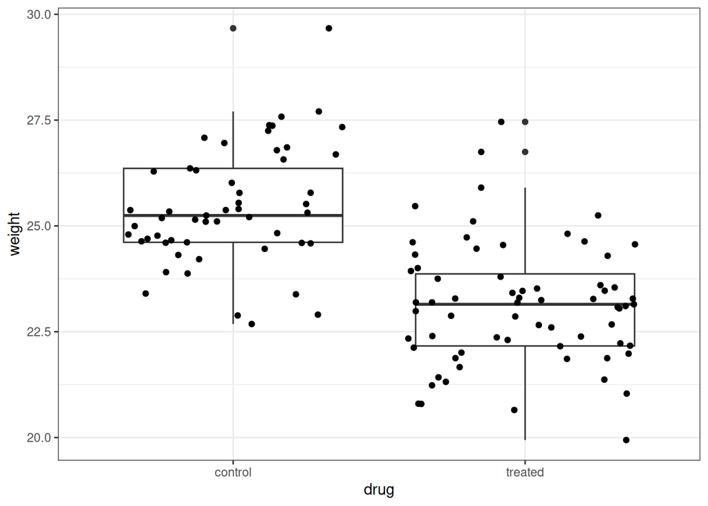

Figure 6: Weight by Drug Treatment

```r
ggplot(nested_data, aes(x = drug, y = weight)) +
  geom_boxplot() +
  geom_jitter() +
  theme_bw()
```

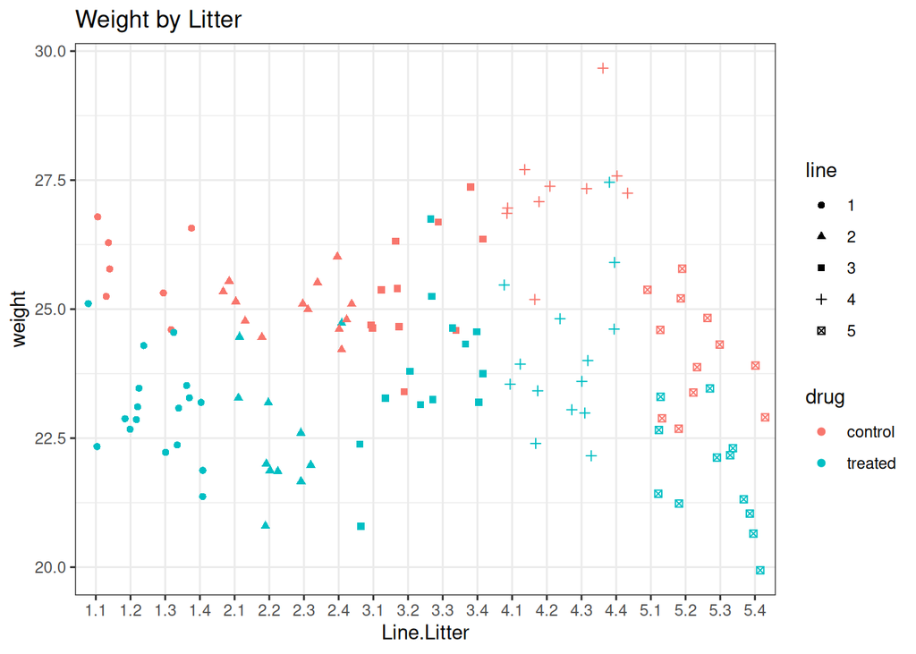

Figure 7: Weight by Litter and Drug Treatment

```r
ggplot(nested_data, aes(x = litter_id, y = weight, color = drug, shape=line)) +
  geom_jitter() +
  labs(title = "Weight by Litter", x = "Line.Litter") +
  theme_bw()
```

Fit three different models:

1. A linear regression model ignoring the grouping structure.
2. A linear mixed model with a random intercept for litter nested within line.
3. A linear mixed model with a random intercept and random slope for drug treatment for litters nested within lines.

**Code**

```r
# Model 1: Ignore nesting
m0 <- lm(weight ~ drug, data = nested_data)

# Model 2: Random intercept for litter (nested within line)
m1 <- lmer(weight ~ drug + (1 | line/litter_id), data = nested_data)
# Compare to this notation
m1_alt <- lmer(weight ~ drug + (1 | line) + (1 | litter_id:line), data = nested_data)
# or
m1_alt2 <- lmer(weight ~ drug + (1 | line) + (1 | litter_id), data = nested_data)

# Model 3: Add random slope for drug per line
m2 <- lmer(weight ~ drug + (1 + drug | line/litter_id), data = nested_data)
```

```
boundary (singular) fit: see help('isSingular')
```

Use `summary()` to study the different models and `anova()` to compare the linear mixed models with different random-effects structures.

**Code**

```r
summary(m0)
```

```
Call:
lm(formula = weight ~ drug, data = nested_data)

Residuals:
    Min      1Q  Median      3Q     Max
-3.1747 -0.8468 -0.0684  0.8763  4.3433

Coefficients:
            Estimate Std. Error t value Pr(>|t|)
(Intercept)  25.4423     0.1947  130.65  < 2e-16 ***
drugtreated  -2.3272     0.2606   -8.93 6.75e-15 ***
---
Signif. codes:  0 '***' 0.001 '**' 0.01 '*' 0.05 '.' 0.1 ' ' 1

Residual standard error: 1.418 on 118 degrees of freedom
Multiple R-squared:  0.4032,    Adjusted R-squared:  0.3982
F-statistic: 79.74 on 1 and 118 DF,  p-value: 6.745e-15
```

```r
summary(m1)
```

```
Linear mixed model fit by REML ['lmerMod']
Formula: weight ~ drug + (1 | line/litter_id)
   Data: nested_data

REML criterion at convergence: 365.4

Scaled residuals:
     Min       1Q   Median       3Q      Max
-2.06105 -0.62779 -0.05877  0.59189  2.72304

Random effects:
 Groups         Name        Variance Std.Dev.
 litter_id:line (Intercept) 0.4566   0.6757
 line           (Intercept) 0.8129   0.9016
 Residual                   0.9092   0.9535
Number of obs: 120, groups:  litter_id:line, 20; line, 5

Fixed effects:
            Estimate Std. Error t value
(Intercept)  25.4609     0.4520   56.33
drugtreated  -2.3605     0.1904  -12.40

Correlation of Fixed Effects:
            (Intr)
drugtreated -0.235
```

```r
summary(m2)
```

```
Linear mixed model fit by REML ['lmerMod']
Formula: weight ~ drug + (1 + drug | line/litter_id)
   Data: nested_data

REML criterion at convergence: 360

Scaled residuals:
    Min      1Q  Median      3Q     Max
-2.2294 -0.5673 -0.0806  0.6434  2.4779

Random effects:
 Groups         Name        Variance Std.Dev. Corr
 litter_id:line (Intercept) 0.15865  0.3983
                drugtreated 0.20968  0.4579   1.00
 line           (Intercept) 1.17439  1.0837
                drugtreated 0.08797  0.2966   -1.00
 Residual                   0.84284  0.9181
Number of obs: 120, groups:  litter_id:line, 20; line, 5

Fixed effects:
            Estimate Std. Error t value
(Intercept)  25.4883     0.5096   50.02
drugtreated  -2.3550     0.2471   -9.53

Correlation of Fixed Effects:
            (Intr)
drugtreated -0.580
optimizer (nloptwrap) convergence code: 0 (OK)
boundary (singular) fit: see help('isSingular')
```

```r
anova(m1, m2, refit = FALSE)
```

```
Data: nested_data
Models:
m1: weight ~ drug + (1 | line/litter_id)
m2: weight ~ drug + (1 + drug | line/litter_id)
   npar    AIC    BIC  logLik -2*log(L)  Chisq Df Pr(>Chisq)
m1    5 375.44 389.37 -182.72    365.44
m2    9 377.96 403.04 -179.98    359.96 5.4815  4     0.2414
```

1. Why is model 1 more appropriate than model 0?
2. For the random intercept model 1, does line or litter account for more variation in weight?
3. Does adding a random slope for `drug` improve the model fit?
4. Based on the best model, what is the estimated fixed effect of the drug treatment? Interpret it.

**Solutions**

1. **Model `m1` accounts for the nested structure**—ignoring it can underestimate standard errors and inflate Type I error.
2. The `VarCorr(m1)` output shows variance estimates for line and litter. These tell us how much of the total variance in weight is due to those grouping levels.

```r
# Variance components for model m1
print(VarCorr(m1), comp="Variance")
```

```
 Groups         Name        Variance
 litter_id:line (Intercept) 0.45659
 line           (Intercept) 0.81293
 Residual                   0.90917
```

3. **Compare AIC and p-value from the ANOVA.** If model `m2` doesn’t improve AIC much or the p-value is large, the added complexity is not justified.
4. From `summary(m1)`, the fixed effect of `drugtreated` is approximately `-2.3`, indicating that treatment lowers weight by 2 g on average.

## 2.2 Lab, technician and sample

We will use the `faraway` package to analyze a dataset with a hierarchical structure involving laboratory, technician and sample. The dataset `eggs` contains measurements of fat content in egg powder. Four samples, 2 G samples and 2 H samples, were analyzed by six laboratories, each with two technicians. The samples were each divided into two parts and fat content measured in each. The goal is to assess the effect of lab and technician on the fat content.

```r
# Load the faraway package and the eggs dataset
library(faraway)
data("eggs", package = "faraway")
# Display the first few rows of the dataset
head(eggs)
```

```
   Fat Lab Technician Sample
1 0.62   I        one      G
2 0.55   I        one      G
3 0.34   I        one      H
4 0.24   I        one      H
5 0.80   I        two      G
6 0.68   I        two      G
```

Visualize the data.

**Code**

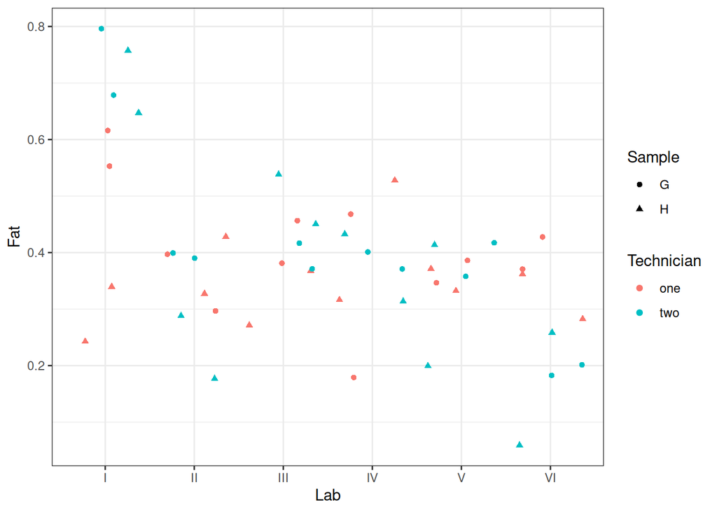

Fat content by Lab and Technician

```r
eggs |> ggplot(aes(x= Lab, y = Fat, color = Technician, shape=Sample)) +
  geom_jitter() +
  theme_bw()
```

What is the grouping structure in the data, and how is it nested? Using this information, fit a linear mixed model.

**Tip**

Replicate measurements are made on samples, samples are handled by technicians, and technicians are nested within laboratories. Thus, the grouping structure is hierarchical, with technician nested within lab, and sample nested within technician within lab.

There are multiple ways to specify the random effects structure, use the method that is least confusing to you!

**Code**

```r
##These two models are equivalent, try it!
mfat <- lmer(Fat ~ 1 + (1|Lab/Technician/Sample), data = eggs)
mfat <- lmer(Fat ~ 1 + (1|Lab) + (1|Lab:Technician) + (1|Lab:Technician:Sample), data = eggs)
```

Examine the model output and interpret the random effects. At what level is the most variation in fat content?

# 3 Model comparisons

## 3.1 Orthodont

Let’s get back to the `Orthodont` dataset in the `nlme` package, which contains measurements of 27 children’s teeth growth over time.

```r
library(nlme)
data("Orthodont", package = "nlme")
summary(Orthodont)
```

[output not shown]

When assessing the change of `distance` with increased `age` it is important to take the grouping structure into account. Each child is measured multiple times, so we need to account for the correlation of measurements within subjects. Add a random intercept for subject and fit a linear mixed model to assess the association between distance and age.

```r
mo1 <- lmer(distance ~ age + (1|Subject), data = Orthodont)
summary(mo1)
```

```
Linear mixed model fit by REML ['lmerMod']
Formula: distance ~ age + (1 | Subject)
   Data: Orthodont

REML criterion at convergence: 447

Scaled residuals:
    Min      1Q  Median      3Q     Max
-3.6645 -0.5351 -0.0129  0.4874  3.7218

Random effects:
 Groups   Name        Variance Std.Dev.
 Subject  (Intercept) 4.472    2.115
 Residual             2.049    1.432
Number of obs: 108, groups:  Subject, 27

Fixed effects:
            Estimate Std. Error t value
(Intercept) 16.76111    0.80240   20.89
age          0.66019    0.06161   10.72

Correlation of Fixed Effects:
    (Intr)
age -0.845
```

There are both boys and girls in the dataset. Your PI wants to estimate the effect of sex on the distance. How could you do this? With random intercept per subject, build models with different sets of fixed effects. Start with only intercept and age, then add also sex and finally also the interaction between age and sex.

```r
mof2 <- lmer(distance ~ age + Sex + (1|Subject), data = Orthodont)
mof3 <- lmer(distance ~ age*Sex + (1|Subject), data = Orthodont)
```

Compare the models using likelihood ratio test. When comparing models with different fixed effects, the comparison should be based on ML rather than REML. Use the `anova`function and remember to set `refit=TRUE as anova will the refit with ML.

What do the results tell you? Which model would you choose?

**Code**

```r
anova(mo1, mof2, mof3, refit = TRUE)
```

```
refitting model(s) with ML (instead of REML)
```

```
Data: Orthodont
Models:
mo1: distance ~ age + (1 | Subject)
mof2: distance ~ age + Sex + (1 | Subject)
mof3: distance ~ age * Sex + (1 | Subject)
     npar    AIC    BIC  logLik -2*log(L)  Chisq Df Pr(>Chisq)
mo1     4 451.39 462.12 -221.69    443.39
mof2    5 444.86 458.27 -217.43    434.86 8.5331  1   0.003488 **
mof3    6 440.64 456.73 -214.32    428.64 6.2174  1   0.012650 *
---
Signif. codes:  0 '***' 0.001 '**' 0.01 '*' 0.05 '.' 0.1 ' ' 1
```

# 4 Computing p-values for mixed models

In this section you will use the `lmerTest` package to compute p-values for mixed models using Satterthwaite’s approximation. This package extends the `lme4` package and provides functions to compute p-values for fixed effects in linear mixed models.

Go back to the exercises “Drug effect on blood pressure” and “Sleep study” and use the `lmerTest` package to compute p-values for the fixed effects in the models you fitted.

# 5 Logistic mixed model

Here we will use the `ohio` dataset in the `faraway` package. This dataset contains information on 537 children and their wheezing status, a binary variable indicating if the child has a pulmonary problem or not). Each child has multiple observations (one for each year from ages 7 to 10, where age 9 is coded as 0). There is also an indicator variable for whether the mother of the child is a smoker.

Take a look at the first two children;

```r
library(faraway)
data("ohio", package = "faraway")
head(ohio, 8)
```

```
  resp id age smoke
1    0  0  -2     0
2    0  0  -1     0
3    0  0   0     0
4    0  0   1     0
5    0  1  -2     0
6    0  1  -1     0
7    0  1   0     0
8    0  1   1     0
```

What would the grouping structure be in this case?

If we ignore the grouping structure, we can fit a logistic regression model using `glm()`:

```r
mohio_glm <- glm(resp ~ age + smoke, family = binomial, data = ohio)
summary(mohio_glm)
```

```
Call:
glm(formula = resp ~ age + smoke, family = binomial, data = ohio)

Coefficients:
            Estimate Std. Error z value Pr(>|z|)
(Intercept) -1.88373    0.08384 -22.467   <2e-16 ***
age         -0.11341    0.05408  -2.097   0.0360 *
smoke        0.27214    0.12347   2.204   0.0275 *
---
Signif. codes:  0 '***' 0.001 '**' 0.01 '*' 0.05 '.' 0.1 ' ' 1

(Dispersion parameter for binomial family taken to be 1)

    Null deviance: 1829.1  on 2147  degrees of freedom
Residual deviance: 1819.9  on 2145  degrees of freedom
AIC: 1825.9

Number of Fisher Scoring iterations: 4
```

To compute the odds ratios (OR), we exponentiate the coefficients:

```r
exp(coef(mohio_glm))
```

```
(Intercept)         age       smoke
  0.1520213   0.8927821   1.3127689
```

According to this model, does the odds for wheezing increase or decrease with age? What about smoking? Are any of the effects statistically significant?

The above model is however incorrect as it ignores the fact that each child has multiple observations. To take this grouping into account, we can use a mixed model with a random intercept for each child.

```r
mohio <- glmer(resp ~ age + smoke + (1|id), family=binomial, data=ohio)
summary(mohio)
```

```
Generalized linear mixed model fit by maximum likelihood (Laplace
  Approximation) [glmerMod]
 Family: binomial  ( logit )
Formula: resp ~ age + smoke + (1 | id)
   Data: ohio

      AIC       BIC    logLik -2*log(L)  df.resid
   1597.9    1620.6    -794.9    1589.9      2144

Scaled residuals:
    Min      1Q  Median      3Q     Max
-1.4027 -0.1802 -0.1577 -0.1321  2.5176

Random effects:
 Groups Name        Variance Std.Dev.
 id     (Intercept) 5.49     2.343
Number of obs: 2148, groups:  id, 537

Fixed effects:
            Estimate Std. Error z value Pr(>|z|)
(Intercept) -3.37395    0.27496 -12.271   <2e-16 ***
age         -0.17676    0.06797  -2.601   0.0093 **
smoke        0.41478    0.28705   1.445   0.1485
---
Signif. codes:  0 '***' 0.001 '**' 0.01 '*' 0.05 '.' 0.1 ' ' 1

Correlation of Fixed Effects:
      (Intr) age
age    0.227
smoke -0.419 -0.010
```

We compute the ORs:

```r
exp(fixef(mohio))
```

```
(Intercept)         age       smoke
 0.03425393  0.83797708  1.51403850
```

According to this model, do the odds for wheezing increase or decrease with age? What about smoking? What does the model output suggest about the age and smokling effects?